# 1D Plane-Wave Density Functional Theory (DFT) — Toy Model

This notebook implements a **minimal, educational 1D Kohn–Sham DFT solver** using a plane-wave basis. It is designed to help you understand the structure of plane-wave DFT codes, like Quantum ESPRESSO, in a simplified and hackable way.

## Goals

- Understand how **plane waves**, **FFTs**, and **self-consistent field (SCF)** iterations work together.
- Reproduce the **structure** (not full realism) of plane-wave DFT.
- Keep the implementation **minimal** and explicit for learning purposes.

## What We Include

- 1D periodic supercell
- Plane-wave basis with kinetic energy cutoff
- Local external potential (toy pseudopotential)
- Hartree potential (1D Poisson, periodic)
- LDA exchange-correlation (toy functional)
- Self-consistent field (SCF) loop

## What We Omit (on purpose)

- Nonlocal pseudopotentials
- k-point sampling (Gamma only)
- Spin and magnetism
- Advanced mixing (Broyden, DIIS)
- Realistic XC parameterizations

## 1. Import Libraries

```python
import numpy as np
from numpy.fft import fft, ifft, fftfreq
from scipy.linalg import eigh
import matplotlib.pyplot as plt
```

## 2. Parameters, Simulation Cell, Grids, and Initialization

We define the number of electrons, periodic box length, real-space grid, and reciprocal-space grid.

```
Occupation numbers: [2.0, 2.0, 2.0, 2.0, 2.0, 2.0, 2.0, 2.0, 1.0]
```

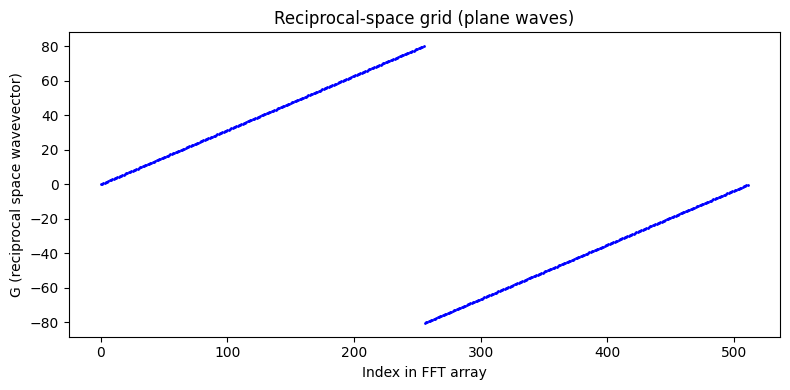

```python
# Control Hartree and XC potentials
TURN_ON_HARTREE = True
TURN_ON_XC = True

# Number of electrons
Ne = 17 # note: max is Ecutoff * 2 + 2

def neutral_ground_state_occupation(Ne):
    n_fully_occupied_band  = Ne // 2
    n_singly_occupied_band = Ne % 2
    occ = [2.0] * n_fully_occupied_band + [1.0] * n_singly_occupied_band
    return occ

occ = neutral_ground_state_occupation(Ne)
print("Occupation numbers:", occ)

# Supercell length (atomic units)
L = 20.0

# Real-space grid
Nx = 512
x = np.linspace(0, L, Nx, endpoint=False)
dx = L / Nx

# Plot dots instead of lines
plt.figure(figsize=(8,4))
plt.scatter(range(len(G)), G, marker='o', color='blue', s=1)  # s = size of dot
plt.xlabel("Index in FFT array")
plt.ylabel("G (reciprocal space wavevector)")
plt.title("Reciprocal-space grid (plane waves)")
plt.tight_layout()
plt.show()
```

## 3. Plane-Wave Cutoff

We define a kinetic energy cutoff $E_{\rm cut}$ in atomic units and select plane waves satisfying $$\frac{|G|^2}{2} \le E_{\rm cut}$$

```python
Ecut = 80.0  # kinetic energy cutoff (a.u.)
pw_mask = 0.5 * G**2 <= Ecut
G_pw = G[pw_mask]
Np = len(G_pw)
print(f"Number of plane waves: {Np}")
```

```
Number of plane waves: 81
```

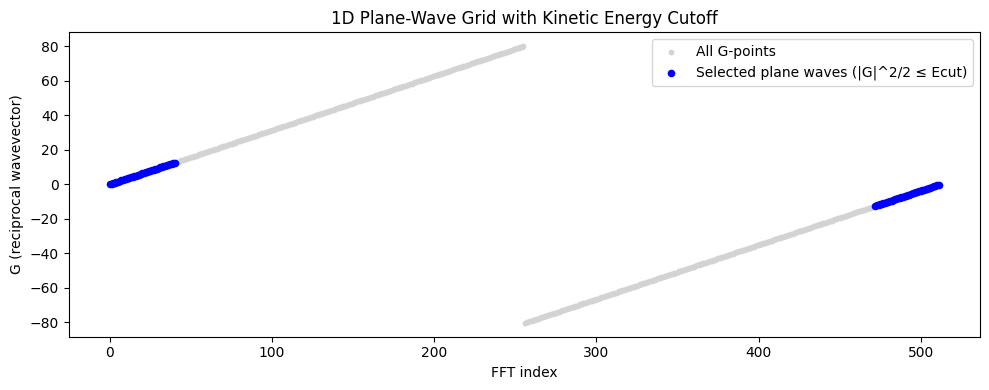

```python
# -----------------------------
# Plot
# -----------------------------
plt.figure(figsize=(10,4))

# Plot all G points in gray
plt.scatter(range(len(G)), G, marker='o', color='lightgray', s=10, label='All G-points')

# Highlight plane waves within kinetic energy cutoff
plt.scatter(np.where(pw_mask)[0], G_pw, marker='o', color='blue', s=20, label='Selected plane waves (|G|^2/2 ≤ Ecut)')

plt.xlabel("FFT index")
plt.ylabel("G (reciprocal wavevector)")
plt.title("1D Plane-Wave Grid with Kinetic Energy Cutoff")
plt.legend()
plt.tight_layout()
plt.show()
```

## Visualizing Plane Waves in Real Space

In plane-wave DFT, the Kohn–Sham orbitals are expanded in a basis of **plane waves**:

$$ \psi(x) = \sum_G C_G \, e^{i G x} $$

where (G) are the **reciprocal lattice vectors** or **repiprocal-space wavevectors**. They correspond with the plane wave $\phi_{G}(x) = e^{iGx}$. In a 1D periodic supercell of length (L) with (N_x) grid points, the allowed (G) values are:

$$ G = \frac{2 \pi}{L} k, \quad k = -\frac{N_x}{2}, \dots, \frac{N_x}{2}-1 $$

or equivalently in Python:

```
G = 2 * np.pi * np.fft.fftfreq(Nx, d=L/Nx)
```

Here, $\phi(x) = e^{iGx} = cos(Gx) + i sin(Gx)$ is complex with:

- Real part: $cos(Gx)$
- Imaginary part: $sin(Gx)$

 Plotting these functions in real space helps visualize the oscillatory nature of plane waves. Higher $|G|$correspond to faster oscillations, which are necessary to capture fine features of the density or potential.

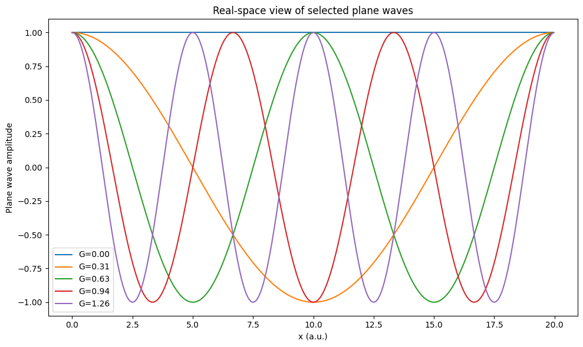

```python
# -----------------------------
# Plot a few selected plane waves
# -----------------------------
plt.figure(figsize=(10,6))

# Plot first few positive and negative plane waves
for i, g in enumerate(G_pw[:5]):   # first 10 plane waves
    plt.plot(x, np.cos(g*x), label=f"G={g:.2f}")

plt.xlabel("x (a.u.)")
plt.ylabel("Plane wave amplitude")
plt.title("Real-space view of selected plane waves")
plt.legend()
plt.tight_layout()
plt.show()
```

## 4. External Potential

We use a smooth Gaussian potential as a toy local pseudopotential: $$V_{\rm ext}(x) = V_0 \exp\Big[-\frac{(x-x_0)^2}{2\sigma^2}\Big]$$

```python
V0 = -5.0
sigma = 0.5
x0 = L / 2

V_ext = V0 * np.exp(-((x - x0)**2)/(2*sigma**2))
V_ext_G = fft(V_ext) / Nx
```

## 5. Hartree Potential (1D)

The Hartree potential satisfies the 1D Poisson equation for periodic density: $$\frac{d^2 V_H}{dx^2} = -4\pi n(x)$$ and in reciprocal space: $$V_H(G) = \frac{4\pi n(G)}{G^2}, \quad G \ne 0$$

```python
def hartree_potential(n):
    nG = fft(n)
    VH_G = np.zeros_like(nG, dtype=complex)
    if not TURN_ON_HARTREE:
        return np.zeros_like(n)
    for i, g in enumerate(G):
        if abs(g) > 1e-12:
            VH_G[i] = 4.0 * np.pi * nG[i] / (g**2)
    VH = np.real(ifft(VH_G))
    return VH
```

## 6. Exchange-Correlation Potential (Toy LDA)

We define a simple LDA-like functional: $$E_{xc}[n] = -A \int n(x)^{4/3} dx, \quad V_{xc} = \frac{dE_{xc}}{dn} = -\frac{4}{3} A n^{1/3}$$

```python
A_xc = 0.75
def v_xc(n):
    if TURN_ON_XC:
        return -(4/3) * A_xc * np.maximum(n, 1e-10)**(1/3)
    return np.zeros_like(n)
```

## 7. Kohn–Sham Hamiltonian

The Hamiltonian in plane-wave basis is: $$H_{GG'} = \frac{G^2}{2} \delta_{GG'} + V_{\rm eff}(G-G')$$

```python
def ks_hamiltonian(Veff):
    Veff_G = fft(Veff) / Nx
    H = np.zeros((Np, Np), dtype=complex)
    for i, Gi in enumerate(G_pw):
        H[i, i] = 0.5 * Gi**2
        for j, Gj in enumerate(G_pw):
            dG = Gi - Gj
            idx = np.where(np.isclose(G, dG))[0]
            if idx.size > 0:
                H[i, j] += Veff_G[idx[0]]
    return H
```

## 8. Density from Orbitals

Compute the electron density from Kohn–Sham orbitals $\psi_i(x)$ and occupations $f_i$: $$n(x) = \sum_i f_i |\psi_i(x)|^2$$

```python
def density_from_orbitals(C, occ):
    n = np.zeros(Nx)
    for i in range(len(occ)):
        psiG = np.zeros(Nx, dtype=complex)
        psiG[pw_mask] = C[:, i]
        psi = ifft(psiG)  # * Nx optional depending on FFT normalization
        n += occ[i] * np.abs(psi)**2
    return n
```

## 9. Self-Consistent Field (SCF) Loop

Iterate until density converges:

```
Iteration   0: E0 = -4.087602   delta_n = 7.512e-01
Iteration   1: E0 = -3.980657   delta_n = 5.259e-01
Iteration   2: E0 = -3.885853   delta_n = 3.681e-01
Iteration   3: E0 = -3.801786   delta_n = 2.577e-01
Iteration   4: E0 = -3.727224   delta_n = 1.804e-01
Iteration   5: E0 = -3.661082   delta_n = 1.263e-01
Iteration   6: E0 = -3.602404   delta_n = 8.838e-02
Iteration   7: E0 = -3.550346   delta_n = 6.187e-02
Iteration   8: E0 = -3.504164   delta_n = 4.331e-02
Iteration   9: E0 = -3.463201   delta_n = 3.032e-02
Iteration  10: E0 = -3.426874   delta_n = 2.122e-02
Iteration  11: E0 = -3.394673   delta_n = 1.485e-02
Iteration  12: E0 = -3.366145   delta_n = 1.040e-02
Iteration  13: E0 = -3.340893   delta_n = 7.279e-03
Iteration  14: E0 = -3.318567   delta_n = 5.095e-03
Iteration  15: E0 = -3.298863   delta_n = 3.567e-03
Iteration  16: E0 = -3.281515   delta_n = 2.497e-03
Iteration  17: E0 = -3.266294   delta_n = 1.748e-03
Iteration  18: E0 = -3.253001   delta_n = 1.223e-03
Iteration  19: E0 = -3.241466   delta_n = 8.563e-04
Iteration  20: E0 = -3.231540   delta_n = 5.994e-04
Iteration  21: E0 = -3.223092   delta_n = 4.196e-04
Iteration  22: E0 = -3.215999   delta_n = 2.937e-04
Iteration  23: E0 = -3.210140   delta_n = 2.056e-04
Iteration  24: E0 = -3.205391   delta_n = 1.439e-04
Iteration  25: E0 = -3.201618   delta_n = 1.007e-04
Iteration  26: E0 = -3.198682   delta_n = 7.052e-05
Iteration  27: E0 = -3.196443   delta_n = 4.937e-05
Iteration  28: E0 = -3.194765   delta_n = 3.456e-05
Iteration  29: E0 = -3.193528   delta_n = 2.419e-05
Iteration  30: E0 = -3.192628   delta_n = 1.693e-05
Iteration  31: E0 = -3.191979   delta_n = 1.185e-05
Iteration  32: E0 = -3.191515   delta_n = 8.297e-06
Iteration  33: E0 = -3.191185   delta_n = 5.808e-06
Iteration  34: E0 = -3.190952   delta_n = 4.066e-06
Iteration  35: E0 = -3.190787   delta_n = 2.846e-06
Iteration  36: E0 = -3.190671   delta_n = 1.992e-06
Iteration  37: E0 = -3.190590   delta_n = 1.394e-06
Iteration  38: E0 = -3.190533   delta_n = 9.761e-07
SCF converged in 39 iterations (delta_n < 1e-06)
```

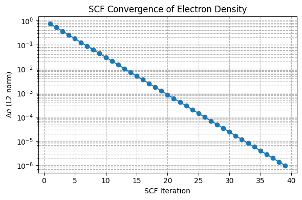

```python
# Initial guess: uniform density
n = np.ones(Nx) * (Ne / L)

alpha = 0.3  # mixing parameter
n_iter = 50
conv_thr = 1e-6

# Track convergence
delta_list = []

for it in range(n_iter):
    # Compute potentials
    VH = hartree_potential(n)
    Vxc = v_xc(n)
    Veff = V_ext + VH + Vxc

    # Build Hamiltonian and diagonalize
    H = ks_hamiltonian(Veff)
    eigvals, eigvecs = eigh(H)

    # Compute new density
    n_new = density_from_orbitals(eigvecs, occ)

    # Compute density difference
    delta = np.linalg.norm(n_new - n) * dx
    delta_list.append(delta)

    # Mix densities
    n = alpha * n_new + (1 - alpha) * n

    print(f"Iteration {it:3d}: E0 = {eigvals[0]:.6f}   delta_n = {delta:.3e}")

    if delta < conv_thr:
        print(f"SCF converged in {it+1} iterations (delta_n < {conv_thr})")
        break

# -----------------------------
# Convergence Plot
# -----------------------------
plt.figure(figsize=(6,4))
plt.semilogy(range(1, len(delta_list)+1), delta_list, marker='o')
plt.xlabel("SCF Iteration")
plt.ylabel(r"$\Delta n$ (L2 norm)")
plt.title("SCF Convergence of Electron Density")
plt.grid(True, which="both", ls="--")
plt.tight_layout()
plt.show()
```

## 10. Plot Final Electron Density

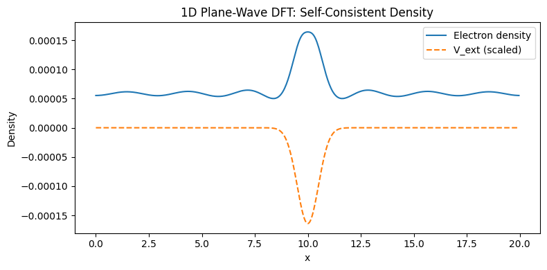

```python
plt.figure(figsize=(8,4))
plt.plot(x, n, label="Electron density")
plt.plot(x, V_ext / np.max(np.abs(V_ext)) * np.max(n), '--', label="V_ext (scaled)")
plt.xlabel("x")
plt.ylabel("Density")
plt.title("1D Plane-Wave DFT: Self-Consistent Density")
plt.legend()
plt.tight_layout()
plt.show()
```

## 11. Plot Kohn–Sham Potential Components

We can visualize $V_{\rm ext}$, $V_H$, $V_{xc}$, and $V_{\rm eff}$.

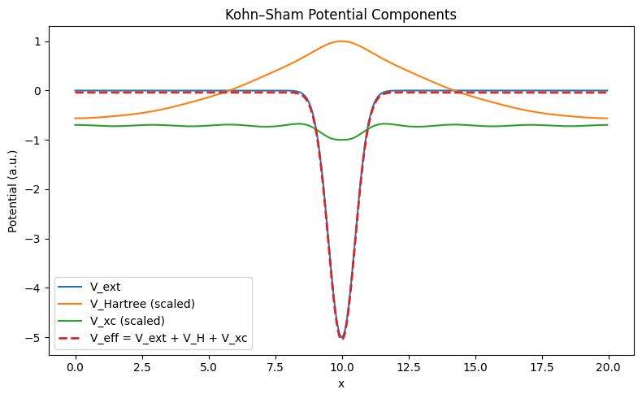

```python
SCALE = True

plt.figure(figsize=(8,5))
plt.plot(x, V_ext, label="V_ext")
if SCALE:
    plt.plot(x, VH / np.max(np.abs(VH)), label="V_Hartree (scaled)")
    plt.plot(x, Vxc / np.max(np.abs(Vxc)), label="V_xc (scaled)")
else:
    plt.plot(x, VH, label="V_Hartree")
    plt.plot(x, Vxc, label="V_xc")

plt.plot(x, Veff, '--', linewidth=2, label="V_eff = V_ext + V_H + V_xc")
plt.xlabel("x")
plt.ylabel("Potential (a.u.)")
plt.title("Kohn–Sham Potential Components")
plt.legend()
plt.tight_layout()
plt.show()
```

## 12. Print Density Table

Similar to QE-style output, we can print $x$ and $n(x)$ side by side.

```python
print("x (a.u.) n(x)")
print("---------------------------")
for i in range(0, Nx, 10):
    print(f"{x[i]:10.6f} {n[i]:12.8f}")
```

```
x (a.u.) n(x)
---------------------------
  0.000000   0.00005523
  0.390625   0.00005629
  0.781250   0.00005877
  1.171875   0.00006102
  1.562500   0.00006153
  1.953125   0.00005991
  2.343750   0.00005717
  2.734375   0.00005515
  3.125000   0.00005527
  3.515625   0.00005758
  3.906250   0.00006060
  4.296875   0.00006225
  4.687500   0.00006122
  5.078125   0.00005798
  5.468750   0.00005466
  5.859375   0.00005370
  6.250000   0.00005618
  6.640625   0.00006073
  7.031250   0.00006413
  7.421875   0.00006326
  7.812500   0.00005763
  8.203125   0.00005111
  8.593750   0.00005241
  8.984375   0.00007431
  9.375000   0.00012281
  9.765625   0.00016021
 10.156250   0.00016256
 10.546875   0.00013322
 10.937500   0.00008222
 11.328125   0.00005469
 11.718750   0.00005039
 12.109375   0.00005619
 12.500000   0.00006246
 12.890625   0.00006437
 13.281250   0.00006162
 13.671875   0.00005701
 14.062500   0.00005393
 14.453125   0.00005421
 14.843750   0.00005724
 15.234375   0.00006070
 15.625000   0.00006228
 16.015625   0.00006111
 16.406250   0.00005819
 16.796875   0.00005559
 17.187500   0.00005497
 17.578125   0.00005665
 17.968750   0.00005939
 18.359375   0.00006136
 18.750000   0.00006130
 19.140625   0.00005929
 19.531250   0.00005672
 19.921875   0.00005528
```